# Unit 2. Directed Acyclic Graphs

UAB, 16-18 June, 2021

## Causal Models

- A causal model (aka structural model) is the system of equations describing the relevant aspects of the world
- It is filled with causal effects associated with comparative statics

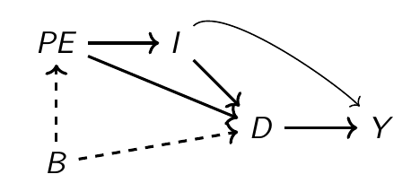

- PE is parental education, I is family income
- D is college education, Y is log wages
- B is unobserved backgroung factors (“ability”)
- Note the arrows (“D is caused by I”) AND the *missing* arrows (why B does not cause Y?)
- Every empirical strategy makes assumptions (debatable author’s belief), but these are **transparent** here.

## Directed Acyclic Graphs (DAGs)

- A DAG is a way to model a system of causal interactions using graphs.
- **Nodes** represent random variables \(X\), \(Y\),…
- **Arrows** or directed edges represent “from \(\rightarrow\) to” causal effects: \(Z\rightarrow X\) reads “\(Z\) causes \(X\)”
- A **path** is a any sequence of edges connecting two nodes: \(Z\rightarrow X \rightarrow M \leftarrow Y\) is a path from \(Z\) to \(Y\).
- In a **direct path** arrows point to the same direction: \(Z\rightarrow X \rightarrow M\)

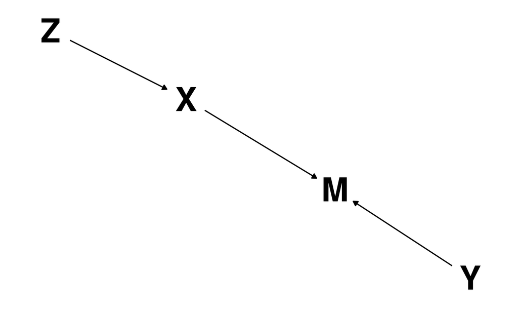

## DAG: more notation

Adjacent nodes

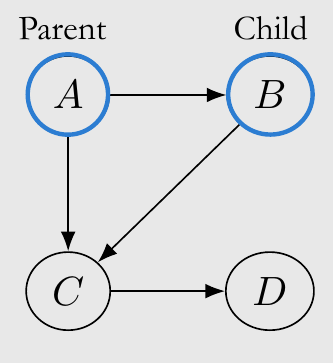

Non-Adjacent nodes

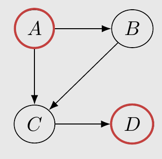

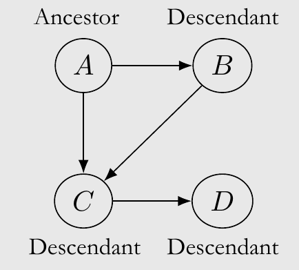

## DAGs: more notation (cont’d)

Cycle

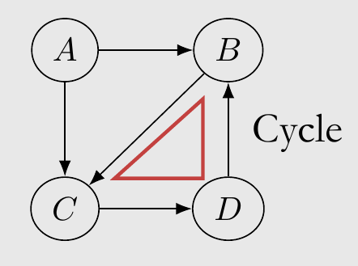

Directed Acyclic Graph (DAG)

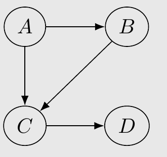

## Confounder DAG

- \(X\) is a common cause of \(D\) and \(Y\).
- Conditioning on \(X\) removes dependency between \(D\) and \(Y\) through \(X\).

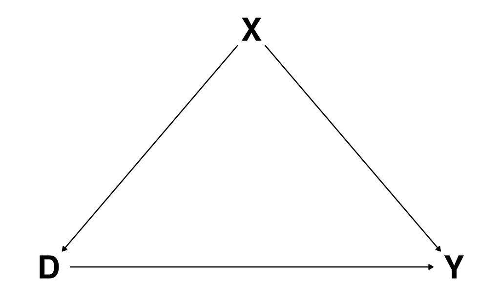

- In DAG terminology, controlling for X “closes the **backdoor path**” between \(D\) and \(Y\), and leaves open the direct path.
- This notion of closing the backdoor path is related to the notion of omitted *variable bias*.

## DAGs and SEM

- DAGs can be considered as non-parametric **structural equation models** (SEM)
- The previous single-confounder DAG can be represented by a set of three equations:

\[ \small \begin{array}{l} X\leftarrow f_X\left(u_{X}\right) \\ D\leftarrow f_D\left(X, u_D\right)\\ Y\leftarrow f_Y(D,X,u_Y) \end{array} \] - \(f_{i}\) denote the causal mechanisms in the model (in general, non-linear)

- \(u_X,u_D\), and \(u_Y\) denote independent background factors that the we chooses not to include in the analysis.
- Assignment operator \((\leftarrow)\) captures asymmetry of causal relationships.

## Unconfoundedness in DAGs

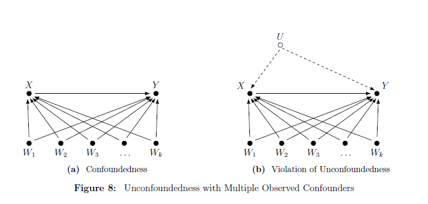

Source: Imbens (2019).

## Example: Identifying the Returns to Education

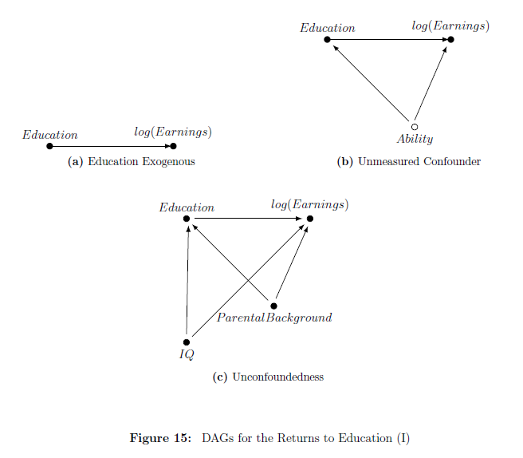

Source: Imbens (2019).

## Instrumental variables in DAGs

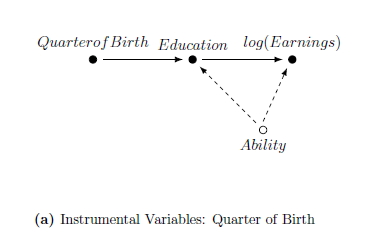

Source: Imbens (2019).

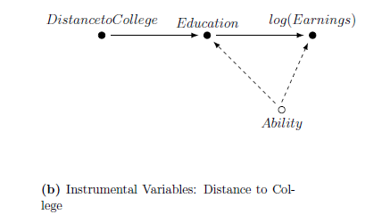

## A mediator

- \(D\) causes \(M\) causes \(Y\).
- \(M\) mediates the causal effect of \(D\) on \(Y\)

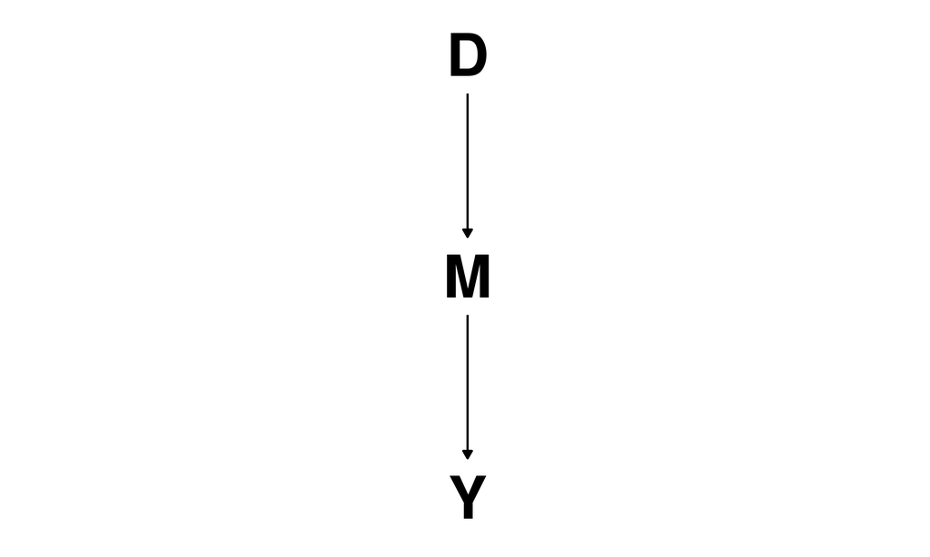

- Conditioning on \(M\) removes dependency between \(D\) and \(Y\)
- In essence, we have closed a direct path (the only direct path between \(D\) and \(Y\)).

## A Collider

- \(D\) are \(Y\) are independent and jointly cause \(C\).

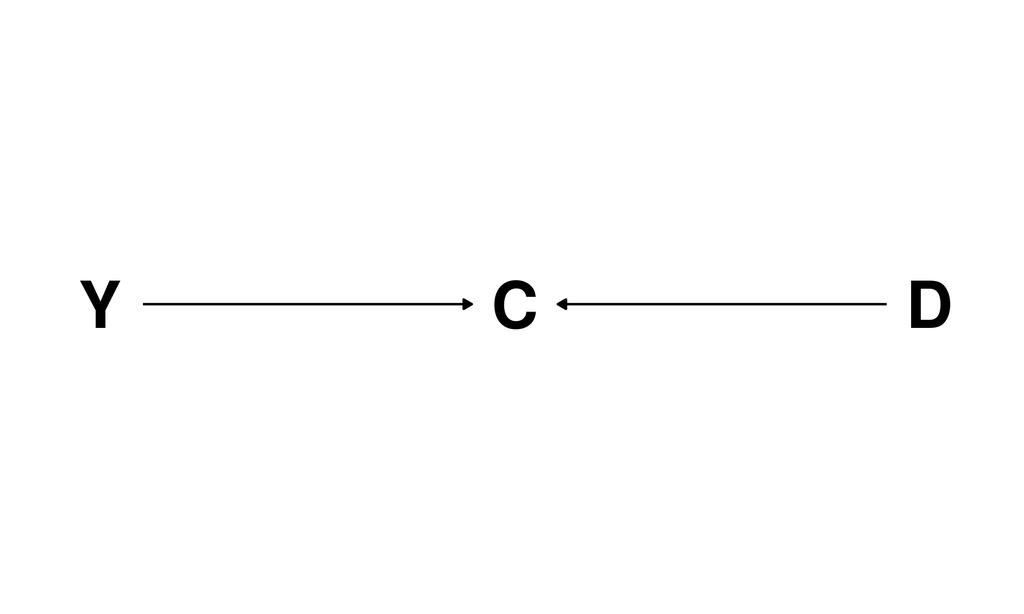

- Conditioning on \(C\) creates dependency between \(D\) and \(Y\)!
- When colliders appear along a backdoor path but are left alone, that backdoor path is closed simply because of their presence.

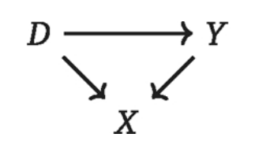

## Examples

- “Bad controls” are variables that are themselves outcome variables.
  - Occupation as control in a return to years of schooling regression.
- Collider: M-bias

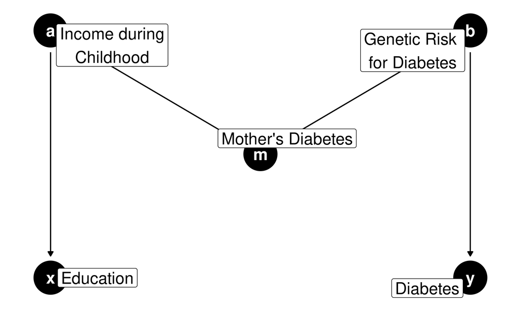

## Backdoor criterion

- Open backdoor paths create systematic, noncausal correlations
- Backdoor paths can be closed by
  1. conditioning on a confounder (“omitted variable bias”)
  2. the simple appearance of a collider in a backdoor path

## Example: the causal effect of education

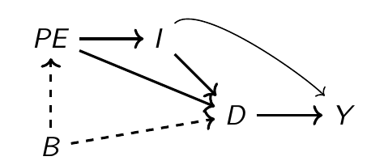

1. D →Y (the causal effect of education on earnings)
2. D ←I→Y (backdoor path 1)
3. D ←PE →I →Y (backdoor path 2)
4. D ←B →PE →I →Y (backdoor path 3)
- By simply controlling by \(I\), you can identify the causal effect

## Example: the causal effect of education (con)

- \(U1\) and \(U2\) are father’s and mother’s *unobserved* genetic ability

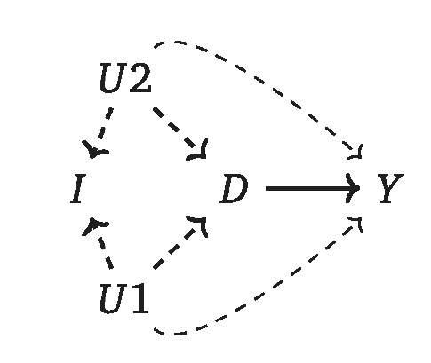

1. D←U2→Y
2. D←U1→Y
3. D←U1→I←U2→Y
4. D←U2→I←U1→Y
- Two open backdoors paths cannot be closed because \(U_i\) are unobserved
- Now controlling by \(I\) only makes things worse because it opens two other backdoor paths

## An example of the collider bias

- Effect of discriminacion (=women) on wages and occupation
- Same ability for men and women

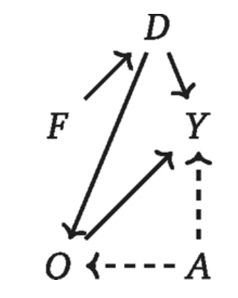

## `dagitty`, `ggdag` and dagitty.net

```r
dag <- dagify(
  D ~ X,
  Y ~ X,
  Y ~ D
)
dag %>%
  ggdag(layout = "tree", text_size = 12, node = FALSE, text_col = "black") +
  theme_dag()
```

```r
collider_triangle(m = "Developer", x = "College", y = "Talent") %>%
  ggdag(use_labels = "label", text_size = 10) +
  theme_dag()
```

```r
m_bias(x = "Education", y = "Diabetes", a = "Income during\nChildhood",
       b = "Genetic Risk \nfor Diabetes", m = "Mother's Diabetes") %>%
  ggdag(text_size = 6, use_labels = "label") +
  theme_dag()
```

## DAG analysis with `dagitty`

- Shortest path, path coefficients identifiable by regressions or by IV, etc.

```r
g1 <- dagitty( "dag {
    W1 -> Z1 -> X -> Y
    Z1 <- V -> Z2
    W2 -> Z2 -> Y
    X <-> W1 <-> W2 <-> Y
}")
g1 %>% ggdag()
for( n in names(g1) ){
    for( m in children(g1,n) ){
        a <- adjustmentSets( g1, n, m, effect="direct" )
        if( length(a) > 0 ){
            cat("The coefficient on ",n,"->",m,
                " is identifiable controlling for:\n",sep="")
            print( a, prefix=" * " )
        }
    }
}
```

## DAGs in other software

- In Python, library `networkx` can define, draw and analyze DAGs

```python
import networkx as nx
from matplotlib import pyplot as plt

graph = nx.DiGraph()
graph.add_edges_from([("X", "Y"), ("X", "D"), ("D", "Y")])

nx.shortest_path(graph, 'X', 'Y')
nx.is_directed_acyclic_graph(graph)

plt.tight_layout()
nx.draw_networkx(graph, arrows=True)
plt.savefig("graph.png", format="PNG")
plt.clf()
```

- [User-written module](https://ideas.repec.org/c/boc/bocode/s458467.html) `dag` exists in Stata for simulating data from DAGs

## Summarizing DAGs

- “Confounders” and "colliders are always context-specific
  - Your dataset will not come with a codebook flagging your variables as one or another
- You do not know in general if you have an omitted variable bias problem
- All identification must be guided by theory, experience, observation, common sense and knowledge of institutions
- DAGs absorb that information and can be then used to write out the explicit identifying model

## Summarizing DAGs (cont’d)

- Values of DAG
  - Make it easier to design an identification strategy for estimating average causal eﬀects
  - Facilitates checking compatibility of the model with your data
  - Visualizes the identifying assumptions which opens up the model to critical scrutiny
- BUT there are limitations: eg., DAGs cannot handle reverse causality or simultaneity
- [“All models are wrong but some are useful”](https://en.wikipedia.org/wiki/All_models_are_wrong)
- IMO, DAGs are helpful and while not necessary

## WAIT: what about estimation?

- We can then use reduced-form causal model to estimate a causal paramater of interest
  - we will discuss several techniques in the rest of the course
- We can also use a structural equation model equivalent to a DAG by imposing further functional form assumpations about the causal relationship
  - In Stata, then `sem` and `gsem` commands allow to design (even graphically) and estimate linear and some non-linear model
  - In R, you have the `lavaan` library
- Remember that you can always get non-linear effects in you linear (in parameters) model by using flexible (local) polynomial approximations.
- Some (non-parametric) machine learning techniques exist to estimate DAGs as Bayesian networks.